# workingBrain: UK Biobank metadata.

## Setup and load data

Load the data and have a look at the first few rows.

| Path | Category | FieldID | Field | Participants | Items | Stability | Value Type | Units | ItemType | Strata | Sexed | Instances | Array | Coding | Notes | Link | inBasket |
| --- | --- | --- | --- | --- | --- | --- | --- | --- | --- | --- | --- | --- | --- | --- | --- | --- | --- |
| UK Biobank Assessment Centre > Procedural metrics > Process durations | 152 | 3 | Verbal interview duration | 501656 | 566685 | Complete | Integer | seconds | Data | Auxiliary | Unisex | 4 | 1 | NA | Time taken for interview | http://biobank.ctsu.ox.ac.uk/showcase/field.cgi?id=3 | FALSE |
| UK Biobank Assessment Centre > Procedural metrics > Process durations | 152 | 4 | Biometrics duration | 497973 | 566546 | Complete | Integer | seconds | Data | Auxiliary | Unisex | 4 | 1 | NA | Time taken for participant to do the tests in the biometric station of the Assessment Centre visit. | http://biobank.ctsu.ox.ac.uk/showcase/field.cgi?id=4 | FALSE |
| UK Biobank Assessment Centre > Procedural metrics > Process durations | 152 | 5 | Sample collection duration | 501327 | 571519 | Complete | Integer | seconds | Data | Auxiliary | Unisex | 4 | 1 | NA | Time taken for participant to complete the blood phlebotomy station of the Assessment Centre visit. This is longer than the time during which they were actively giving blood. | http://biobank.ctsu.ox.ac.uk/showcase/field.cgi?id=5 | FALSE |
| UK Biobank Assessment Centre > Procedural metrics > Process durations | 152 | 6 | Conclusion duration | 499027 | 569096 | Complete | Integer | seconds | Data | Auxiliary | Unisex | 4 | 1 | NA | This is the time taken for the participant to complete the final conclusion stage of the Assessment Centre visit. | http://biobank.ctsu.ox.ac.uk/showcase/field.cgi?id=6 | FALSE |
| UK Biobank Assessment Centre > Physical measures > Bone-densitometry of heel | 100018 | 19 | Heel ultrasound method | 324778 | 324778 | Complete | Categorical single | NA | Data | Primary | Unisex | 1 | 1 | 100260 | Method used for the Ultrasound Bone Densitometry of heel | http://biobank.ctsu.ox.ac.uk/showcase/field.cgi?id=19 | FALSE |
| UK Biobank Assessment Centre > Physical measures > Anthropometry > Body size measures | 100010 | 21 | Weight method | 500841 | 570293 | Complete | Categorical single | NA | Data | Primary | Unisex | 4 | 1 | 100261 | Indicates whether weight was entered into the machine directly or manually, whether weight was only measured manually or not performed | http://biobank.ctsu.ox.ac.uk/showcase/field.cgi?id=21 | FALSE |

These are all the datafields in the UK Biobank data set, so we need to filter for the fields included in our study (i.e. based on the variable ‘inBasket’):

| Path | Category | FieldID | Field | Participants | Items | Stability | Value Type | Units | ItemType | Strata | Sexed | Instances | Array | Coding | Notes | Link | inBasket |
| --- | --- | --- | --- | --- | --- | --- | --- | --- | --- | --- | --- | --- | --- | --- | --- | --- | --- |
| Population characteristics > Baseline characteristics | 100094 | 31 | Sex | 502506 | 502506 | Complete | Categorical single | NA | Data | Primary | Unisex | 1 | 1 | 9 | Sex of participant. Acquired from central registry at recruitment, but in some cases updated by the participant. Hence this field may contain a mixture of the sex the NHS had recorded for the particip… | http://biobank.ctsu.ox.ac.uk/showcase/field.cgi?id=31 | TRUE |
| Population characteristics > Baseline characteristics | 100094 | 34 | Year of birth | 502506 | 502506 | Complete | Integer | years | Data | Primary | Unisex | 1 | 1 | NA | Year of birth of participant. Acquired from central registry, updated by participant. | http://biobank.ctsu.ox.ac.uk/showcase/field.cgi?id=34 | TRUE |
| Population characteristics > Baseline characteristics | 100094 | 52 | Month of birth | 502506 | 502506 | Complete | Categorical single | NA | Data | Primary | Unisex | 1 | 1 | 8 | Calendar month of birth of participant. Acquired from central registry, updated by participant. | http://biobank.ctsu.ox.ac.uk/showcase/field.cgi?id=52 | TRUE |
| UK Biobank Assessment Centre > Recruitment > Reception | 100024 | 53 | Date of attending assessment centre | 502506 | 573525 | Complete | Date | NA | Data | Primary | Unisex | 4 | 1 | NA | Date that participant attended a UK Biobank assessment centre. Automatically acquired at Reception stage. | http://biobank.ctsu.ox.ac.uk/showcase/field.cgi?id=53 | TRUE |
| UK Biobank Assessment Centre > Recruitment > Reception | 100024 | 54 | UK Biobank assessment centre | 502506 | 573520 | Complete | Categorical single | NA | Data | Primary | Unisex | 4 | 1 | 10 | The UK Biobank assessment centre at which participant consented. Automatically acquired at participant consent | http://biobank.ctsu.ox.ac.uk/showcase/field.cgi?id=54 | TRUE |
| Population characteristics > Baseline characteristics | 100094 | 189 | Townsend deprivation index at recruitment | 501883 | 501883 | Complete | Continuous | NA | Data | Derived | Unisex | 1 | 1 | NA | Townsend deprivation index calculated immediately prior to participant joining UK Biobank. Based on the preceding national census output areas. Each participant is assigned a score corresponding to th… | http://biobank.ctsu.ox.ac.uk/showcase/field.cgi?id=189 | TRUE |

## Explore

```
## How many rows does our dataframe have?
```

```
## [1] 480
```

```
## How many columns does our dataframe have?
```

```
## [1] 18
```

```
## How many 'complete cases' (no rows/cols with NA)?
```

```
## [1] 51
```

**What’s the structure of our data?**

This is currently held in the ‘Path’ variable. Will use this to create ‘Medium’ (Population vs Online vs Assessment Centre), ‘MetaCat’ and ‘Category’ variables (i.e. columns), making it more intuitive and removing some of the information that we’re not really interested in (e.g. that that data was aquired through ‘Touchscreen’). More details below.

```
## Full paths before transformation:
```

```
##  [1] "Online follow-up > Cognitive function online > Fluid intelligence / reasoning"
##  [2] "Online follow-up > Cognitive function online > Numeric memory"
##  [3] "Online follow-up > Cognitive function online > Pairs matching"
##  [4] "Online follow-up > Cognitive function online > Symbol digit substitution"
##  [5] "Online follow-up > Cognitive function online > Trail making"
##  [6] "Online follow-up > Mental health > Anxiety"
##  [7] "Online follow-up > Mental health > Depression"
##  [8] "Online follow-up > Mental health > Happiness and subjective well-being"
##  [9] "Online follow-up > Work environment"
## [10] "Online follow-up > Work environment > Employment history"
## [11] "Online follow-up > Work environment > Medical information"
## [12] "Population characteristics > Baseline characteristics"
## [13] "Population characteristics > Baseline characteristics > Indices of Multiple Deprivation"
## [14] "Population characteristics > Ongoing characteristics"
## [15] "UK Biobank Assessment Centre > Cognitive function > Fluid intelligence / reasoning"
```

[output cut: 28 more lines]

**“Wrangling”**

The following are various steps to make the data more intuitive and easier to work with (code provided at https://github.com/factitious/raeBiobank_workingBrain/blob/master/metaData/workingBrain_metaData.Rmd). The main aim is to divide the unhelpful (and in this state unusable) `Path` variable into columns that could actually help us make sense of the data.

Following “wrangling”, our data now has the following structure.

| Medium | MetaCat | Category | CategoryID | FieldID | Field | Participants | Items | Stability | Value Type | Units | ItemType | Strata | Sexed | Instances | Array | Coding | Notes | Link | inBasket |
| --- | --- | --- | --- | --- | --- | --- | --- | --- | --- | --- | --- | --- | --- | --- | --- | --- | --- | --- | --- |
| Population characteristics | Sociodemographics | Baseline | 100094 | 31 | Sex | 502506 | 502506 | Complete | Categorical single | NA | Data | Primary | Unisex | 1 | 1 | 9 | Sex of participant. Acquired from central registry at recruitment, but in some cases updated by the participant. Hence this field may contain a mixture of the sex the NHS had recorded for the particip… | http://biobank.ctsu.ox.ac.uk/showcase/field.cgi?id=31 | TRUE |
| Population characteristics | Sociodemographics | Baseline | 100094 | 34 | Year of birth | 502506 | 502506 | Complete | Integer | years | Data | Primary | Unisex | 1 | 1 | NA | Year of birth of participant. Acquired from central registry, updated by participant. | http://biobank.ctsu.ox.ac.uk/showcase/field.cgi?id=34 | TRUE |
| Population characteristics | Sociodemographics | Baseline | 100094 | 52 | Month of birth | 502506 | 502506 | Complete | Categorical single | NA | Data | Primary | Unisex | 1 | 1 | 8 | Calendar month of birth of participant. Acquired from central registry, updated by participant. | http://biobank.ctsu.ox.ac.uk/showcase/field.cgi?id=52 | TRUE |
| UK Biobank Assessment Centre | Sociodemographics | Baseline | 100024 | 53 | Date of attending assessment centre | 502506 | 573525 | Complete | Date | NA | Data | Primary | Unisex | 4 | 1 | NA | Date that participant attended a UK Biobank assessment centre. Automatically acquired at Reception stage. | http://biobank.ctsu.ox.ac.uk/showcase/field.cgi?id=53 | TRUE |
| UK Biobank Assessment Centre | Sociodemographics | Baseline | 100024 | 54 | UK Biobank assessment centre | 502506 | 573520 | Complete | Categorical single | NA | Data | Primary | Unisex | 4 | 1 | 10 | The UK Biobank assessment centre at which participant consented. Automatically acquired at participant consent | http://biobank.ctsu.ox.ac.uk/showcase/field.cgi?id=54 | TRUE |
| Population characteristics | Sociodemographics | Baseline | 100094 | 189 | Townsend deprivation index at recruitment | 501883 | 501883 | Complete | Continuous | NA | Data | Derived | Unisex | 1 | 1 | NA | Townsend deprivation index calculated immediately prior to participant joining UK Biobank. Based on the preceding national census output areas. Each participant is assigned a score corresponding to th… | http://biobank.ctsu.ox.ac.uk/showcase/field.cgi?id=189 | TRUE |

```
## Full paths after transformation:
```

```
##  [1] "Online follow-up > Cognitive function > Fluid intelligence / reasoning"
##  [2] "Online follow-up > Cognitive function > Numeric memory"
##  [3] "Online follow-up > Cognitive function > Pairs matching"
##  [4] "Online follow-up > Cognitive function > Symbol digit substitution"
##  [5] "Online follow-up > Cognitive function > Trail making"
##  [6] "Online follow-up > Employment > Employment: History"
##  [7] "Online follow-up > Health and medical history > Medical information"
##  [8] "Online follow-up > Mental health > Anxiety"
##  [9] "Online follow-up > Mental health > Depression"
## [10] "Online follow-up > Mental health > Happiness and subjective well-being"
## [11] "Population characteristics > Sociodemographics > Baseline"
## [12] "Population characteristics > Sociodemographics > Indices of Multiple Deprivation"
## [13] "Population characteristics > Sociodemographics > Ongoing"
## [14] "UK Biobank Assessment Centre > Cognitive function > Fluid intelligence / reasoning"
## [15] "UK Biobank Assessment Centre > Cognitive function > Lights pattern memory"
```

[output cut: 26 more lines]

```
## Metacategories after transformation:
```

```
## [1] "Sociodemographics"          "Cognitive function"
## [3] "Employment"                 "Lifestyle and environment"
## [5] "Mental health"              "Health and medical history"
## [7] "Imaging"
```

```
## Categories after transformation:
```

```
##  [1] "Baseline"                            "Ongoing"
##  [3] "Pairs matching"                      "Reaction time"
##  [5] "Household"                           "Employment: Current"
##  [7] "Education"                           "Physical activity"
##  [9] "Social support"                      "Sleep"
## [11] "Smoking"                             "Alcohol"
## [13] "Other"                               "General health"
## [15] "Numeric memory"                      "Prospective memory"
## [17] "Fluid intelligence / reasoning"      "Tower rearranging"
## [19] "Matrix pattern completion"           "Trail making"
## [21] "Symbol digit substitution"           "Paired associate learning"
## [23] "Lights pattern memory"               "Word production"
## [25] "Medical conditions"                  "Task functional brain MRI"
## [27] "Anxiety"                             "Depression"
## [29] "Happiness and subjective well-being" "Ethnicity"
## [31] "Medical information"                 "Employment: History"
## [33] "Resting functional brain MRI"        "Indices of Multiple Deprivation"
```

## Visualize

### circlePacking

Circular packing or circular treemap allows to visualize a hierarchic organization. It is an equivalent of a treemap or a dendrogram, where each node of the tree is represented as a circle and its sub-nodes are represented as circles inside of it.

I thought this would be quite useful for visualising (and hopefully making sense) of our ‘metadata’. The size of the circles can be changed to be proportional to whatever value we choose, but for now I left it as constant as I couldn’t really see any value that we could’ve made the size of the circles dependent on to help with insight.

**Visualising MetaCat/Cat relationship**

[interactive chart not shown]

**Visualising MetaCat/Cat/Fields relationship**

Note: had to use `FieldID` as opposed to `Field`(i.e. field name) to help with visualisation.

[interactive chart not shown]

### Interactive Dendrogram

**There is some problem using two different types of html widgets in the same knit, so for now this will just live in the shiny app: https://munchausend.shinyapps.io/dataViz/**

## Analysis plan

This project *aims* to characterize the neurophysiological processes through which occupational factors affect our health and wellbeing, with the following *objectives*:

1. **Identify occupational factors that have a meaningful impact on neuronal function and describe the mechanism of impact.**
2. **Assess how physiological inflammatory responses are altered by occupational factors.**
3. **Determine how the identified neuronal and inflammatory markers jointly affect our physical and mental health.**

Progress against these objectives will help develop a holistic insight into why our wellbeing is affected by modern work patterns and other occupational factors.

Therefore, our main question is what occupational factors affect neurophysiology and how? In the current case (i.e. UKBB dataset), our occupational factors will be under the metaCat *Employment*, our neurohysiology measures are *C-Reactive Protein (CRP)* and brain imaging (*task + resting-state MRI*).

In order to determine how particular work patterns are associated with neural markers, immune function, and cognition, we need to first understand how numerous non-imaging/-physiological variables inter-relate in our Biobank dataset. This includes employment, sociodemographic, lifestyle, and health-related information. The complete list of data fields requested from the Biobank for this project can be found at http://tiny.cc/UKBBMetaData_62188 (N.B.:“Participants” attribute refers to total participants in the cohort with information in the selected “Field”, not the number of participants in the dataset linked to the current project).

Therefore, prior to analysing the imaging and physiological data, we will undertake a comprehensive investigation of how employment variables (e.g. ‘Length of working week for main job’; Biobank Field ID: 767) relate to sociodemographic, lifestyle, and health-related information, in our dataset of n = 35, 501 individuals. To do so, we plan to use multivariate analysis techniques, incorporating machine learning methods, potentially applying a Canonical Correlational Analysis (CCA) approach.

### Proposed strategies

In order to determine how particular occupational factors are associated with neural markers, immune function, and cognition, we need to first understand how numerous non-imaging/-physiological variables inter-relate in our Biobank dataset. This includes employment, sociodemographic, lifestyle, and health-related information. Given the complexity of our data and underlying causal relationships between its features (see assumptions below), we are considering several different strategies for this stage of our analysis, outlined below.

#### Feature selection/extraction using prior domain-specific knowledge.

- In this approach we would qualitatively assess fields in the meta-categories of interest (i.e. *Employment*, *Sociodemographics*, *Lifestyle and environment*, and *Health and medical history*). Using prior domain-specific knowledge (e.g. published literature), together with descriptive (uni and bivariate) statistics and visualization tools, we would then choose (a likely small) number of features from each meta-category to include in our subsequent (fairly simple) imaging/physiology models, e.g. GLM, following normalisation and other pre-processing steps.

*Pros*:

- Easy to interpret
- Implementation is straightforward (ish)
- Know how to do
- Likely scales well
- Will probably need to do some version of this regardless of what strategy we choose

*Cons:*

- Could be missing out on a lot of valuable information
- Difficult to look at multi-variate relationships
- We could end up with masked relationships due to missing features/information*
- Biased by being heavily reliant on prior knowledge

* When trying to measure the influences of multiple factors on an outcome, sometimes none of those influences is apparent from the bivariate relationships alone (i.e. $outcome$ ~ $feature1$; $outcome$ ~ $feature2$). This kind of problem tends to arise when there are two features that are correlated with the outcome, one positively and the other one negatively, while the two features are also positively correlated with one another.In this case the effect of either feature is apparent only when conditioning on the other feature as well (i.e. $outcome$ ~ $feature1 + feature2$), which in a GLM is asking: “What is the effect of *feature1* on our *outcome* after taking into account *feature2*?” (and vice-versa). For a detailed example see Chapter 5, section 2 of [this](https://xcelab.net/rm/statistical-rethinking/)

#### Canonical Correlation Analysis (CCA).

- Another option for understanding the relationships b/n our non-imaging features would be to perform a CCA with a set of *Employment* features on one hand and set of *Sociodemographics*, *Lifestyle and environment*, and *Health and medical history* features on the other. Below is an description of the main idea behind CCA. Along with the Pros and Cons stated below, I am not sure CCA is appropriate for the current situation overall: it’s used when there’s a many-to-many relationship, but we have a one-to-many relationship at this stage (i.e. one *Employment* feature ~ many non-imaging/physiology/employment features). More appropriate for subsequent stage, i.e. imaging analysis?

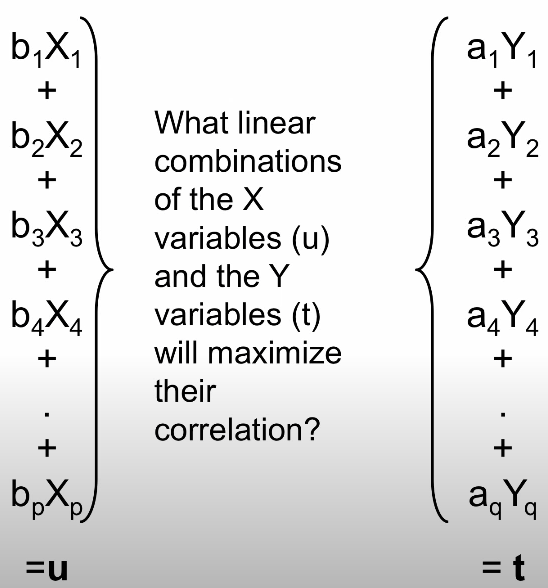

- We are trying to maximize $R_c$, which is the linear correlation (Pearson’s $r$) b/n two variates ($u; \: t$). These variates are weighted ($b1...bp; \: sa1...aq$) linear composites of each set of variables ($X_1...X_p; \: Y_1...Yq$).

My main concern is interpretability - aren’t we dealing with the same issue as in PCA or any other analysis method focused on latent space? i.e. following decomposition/re-expression the meaning of your features is lost, you instead get components which are a (linear) combinations of your initial features. **Answer: No.**

In the case of CCA you can still relate your variates to the original features through:

- canonical weights = e.g. unique partial contribution of X1 to u (equivalent to $\beta$ in a regression model); e.g. the $b1...bp$’s above.
- canonical loadings = direct contribution of one feature to its respective canonical variate regardless of other features (interpreted as in PCA); e.g. $corr(X_1,u)$.
- canonical cross-loadings = direct contribution of one feature to the “opposite” variate (i.e. the one it is not a part of); e.g. $corr(Y_1, u)$.

The most accessible explanation + more detail is in the *Where does the Effect Come From?* section of [this](https://www.tandfonline.com/doi/abs/10.1207/s15327752jpa8401_09) paper. See also:

- [Hao-Ting’s primer](https://doi.org/10.1016/j.neuroimage.2020.116745)
- [Primer more focused on psych](https://www.tandfonline.com/doi/abs/10.1207/s15327752jpa8401_09)
- Use in cog neuro, [here](https://www.nature.com/articles/s41598-020-67605-2).
- Review for cog neuro applications [here](https://onlinelibrary.wiley.com/doi/full/10.1002/hbm.25090)
- “Famous” Smith paper using it [here](http://www.nature.com/articles/nn.4125).

*Pros*:

- All information is included in the assessment
- A powerful way to describe the structure b/n and w/n in two sets of features **simultaneously**

*Cons*:

- Interpretation is difficult (lacks specificity).
- Assumes linear relationship b/n any two variables and between variates.
- Multicollinearity in either variate confounds interpretation of canonical results + leads to instability.
- However, all the features in a set (e.g. all X’s) have to be interrelated (there has to be some correlation) - but not so much as to cause multicollinearity.
- Choosing composition (X’s and Y’s) is difficult.
- No precise statistics for interpretation of CCA -> reliant on descriptives.
- Not appropriate when a single variable constitutes a “variate” i.e. can’t have a single X or a single Y; a single IV or a single DV. In that case, multiple GLMs are more appropriate.

#### Factor analysis/SEM.

- The goal of factor analysis/SEM is to model the relationship between measured variables/features and latent constructs. From my (limited) understanding, the two are similar, but SEM also attempts to also look at “structural” relationship b/n features and/or factors to determine causality.

On factor analysis, from this [tutorial](https://stats.idre.ucla.edu/spss/seminars/introduction-to-factor-analysis/a-practical-introduction-to-factor-analysis/):

- Similar to PCA, but the partitioning of variance is done differently: both methods try to reduce the dimensionality of the dataset to fewer unobserved variables, but whereas PCA assumes that there common variances takes up all of total variance, common factor analysis assumes that total variance can be partitioned into common and unique variance (the unobserved or latent variable that makes up common variance is called a factor, hence the name factor analysis).
- The other main difference between PCA and factor analysis lies in the goal of your analysis. If your goal is to simply reduce your variable list down into a linear combination of smaller components then PCA is the way to go. However, if you believe there is some latent construct that defines the interrelationship among items, then factor analysis may be more appropriate.

*Pros:*

- Can investigate **mediated**, as well as direct, effects of some features on other features.
- Used for complex, multi-faceted constructs that are measured with error.
- Ablility to model “systems” of relationships rather than a DV and a set of IVs.

*Cons:*

- Need to learn, might be quite time-consuming.
- Unknown cons (as I don’t understand it fully yet).

#### Other

- Multilevel modelling.
- ??

### Proposed DAGs.

I will be using directed acyclic graphs (DAGs), which provide visual representations of our **causal assumptions**, to help make sense of the data and keeping track of the “big picture”. This will necessarily be an oversimplification of any underlying truth.

For a good intro on DAG + my reasoning, see [Rohrer, J. M. (2018). Thinking Clearly About Correlations and Causation: Graphical Causal Models for Observational Data. Advances in Methods and Practices in Psychological Science, 1(1), 27–42](https://doi.org/10.1177/2515245917745629) or e.g. Judea Pearl’s “Book of Why”.

Help with implementation [here](https://rdrr.io/cran/ggdag/), [here](https://cran.r-project.org/web/packages/ggdag/ggdag.pdf), [here](https://cran.r-project.org/web/packages/ggdag/vignettes/intro-to-ggdag.html), and [here](https://ggdag.malco.io/articles/bias-structures.html).

#### Objective 1: Identify occupational factors that have a meaningful impact on neuronal function and describe the mechanism of impact.

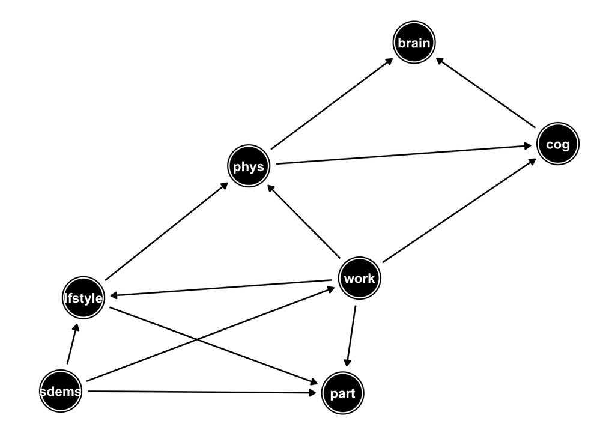

- “work” = “Occupational Factors / Employment” == **exposure**,
- “lfstyle” = “Lifestyle and Environment”,
- “sdems” = “Sociodemographics”,
- “brain” = “Brain Imaging (tf/rs-fMRI)” == **outcome**,
- “phys” = “Physiology”,
- “cog” = “Cognition &Affect”,
- “part” = “Participation”: unobserved (i.e. latent) variable.

Note on “part”: I’m making the assumption that sociodemographic, work, and lifestyle factors determined whether a participant volunteered for the UKBB cohort or not, and also whether they went through with follow-up requests (e.g. coming back for the “Imaging” visit after “Baseline” assessments). Unfortunately, we do not have any information on people that declined the invitation to volunteer for the UKBB, or the ones who declined follow-up (although there’s some details in Littlejohns, T. J., et atl, 2020; https://doi.org/10.1038/s41467-020-15948-9). I’m including this to underlie potential/probable bias in our data, namely:

- post-selection bias: “part” is a hidden collider, and since we are conditioning on it (i.e. we’re only looking at people *in* the UKBB cohort), it will likely biases our models. Also: no-response, misrepresentativeness, attrition biases (could have different variables for these, but not useful at this stage).

**#TODO#** “part” appears to be a back-door only through “lifestyle”, so we should actually be fine as long as we properly controll for lifestyle factors)? This “takes care” of post-selection but what about the other ones? - I think so! Again, as long as we can (appropriately) control for lifestyle factors. Feels counter-intuitive though - maybe it’s just me but selection bias is confusing in these terms. Will need an opinion on this.

Unclear what the best way to think about cognitive measures is in the current circumstances. Most likely a bi-directional relationship in the case of brain ~ cog measures (i.e. brain <-> cognition), but which is more relevant to the current situation (brain -> cog, cog -> brain).

Conditional independencies in the DAG:

```
## bran _||_ lfst | phys, work
## bran _||_ lfst | cog, phys
## bran _||_ sdms | lfst, work
## bran _||_ sdms | phys, work
## bran _||_ sdms | cog, phys
## bran _||_ work | cog, phys
## cog _||_ lfst | phys, work
## cog _||_ sdms | lfst, work
## cog _||_ sdms | phys, work
## phys _||_ sdms | lfst, work
```

I am having difficulties vizualizing all potential paths when knitting, so will have to skip in published notebook - code provided at https://github.com/factitious/raeBiobank_workingBrain/blob/master/metaData/workingBrain_metaData.Rmd).

(If the current DAG and related assumptions are correct) The sets of covariates that, when adjusted for, block all back-door paths, and include no more or no less information than necessary to determine the causal link b/w *Work* and *Brain* (i.e. minimally sufficient adjustment set) are:

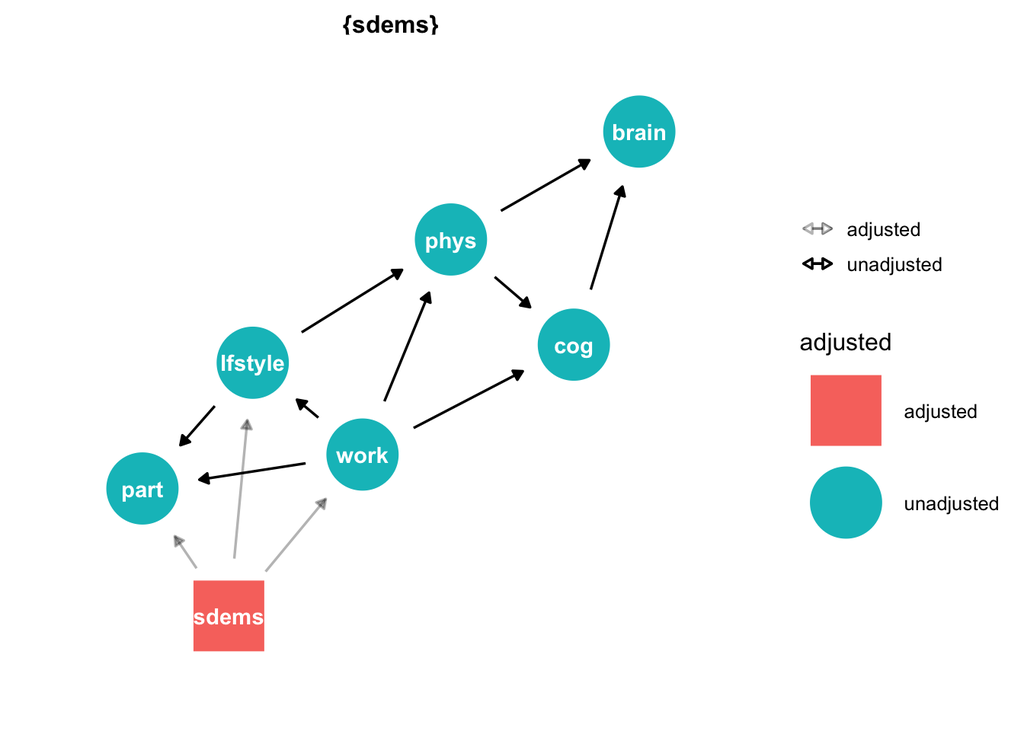

- so adjusting/conditioning/controlling for **sdems** closes all the backdoor paths, i.e. we only need to adjust for *Sociodemographics* in order to assess the effect of work on the brain.

Of course, as I mentioned initially, this will tell us nothing about the mechanism through which work affects the brain (which is what we actually care about). The same is true for the other objectives re *phys* (i.e. Physiology) and joint effect of the two (below). Therefore, I think we will need mediation analysis (e.g. in the form of SEM) to investigate this further??

Also, we need a way to decide on how to condition on the lifestyle features (e.g. stratification; inclusion in regression models). Likely should just rely on prior knowledege as (computational) dimensionality reduction techniques (e.g. PCA, ICA) are not great when it comes to interpretability.

#### Objective 2: Assess how physiological inflammatory responses are altered by occupational factors.

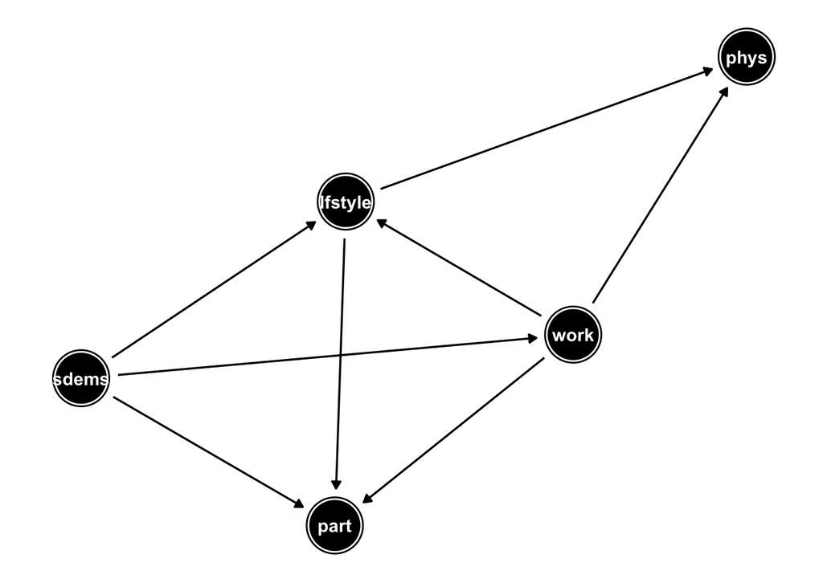

```
## phys _||_ sdms | lfst, work
```

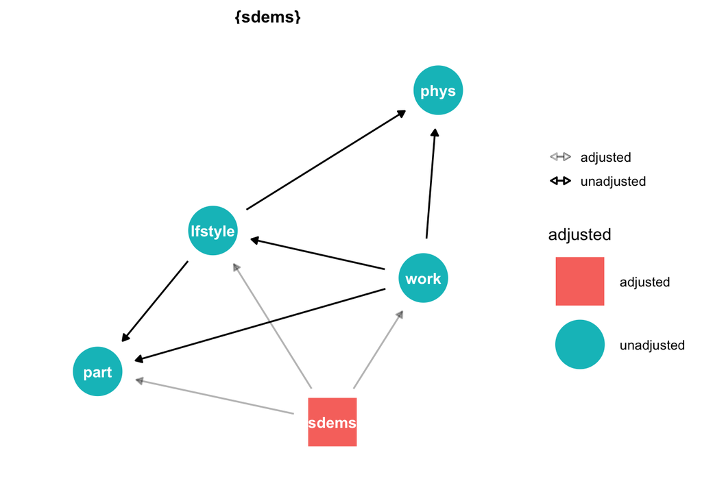

#### Objective 3: Determine how the identified neuronal and inflammatory markers jointly affect our physical and mental health.

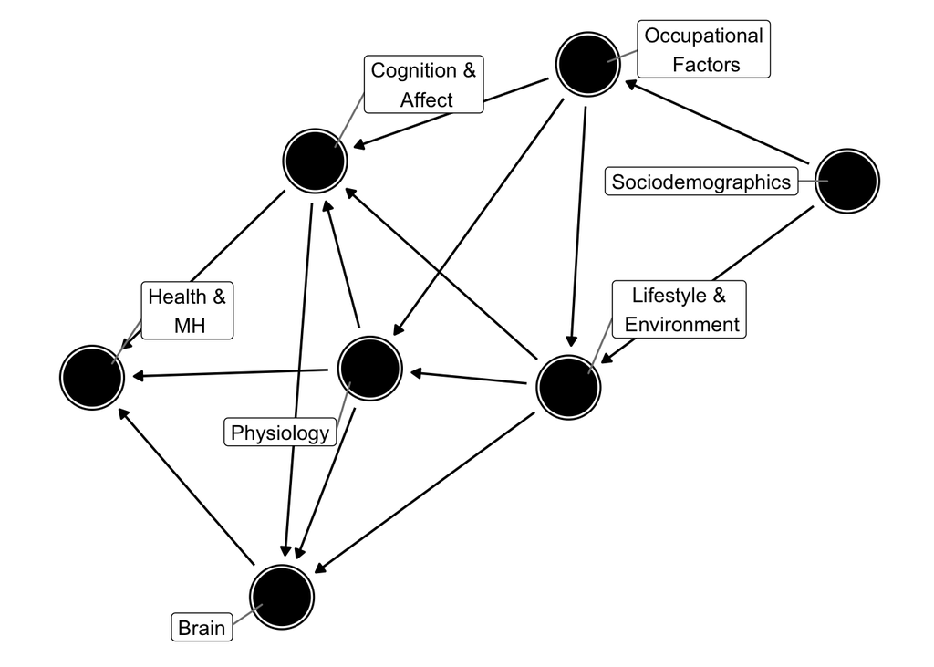

- N.B.: I’ve removed “part” from the graph as it makes visualizing more difficult.

```
## bran _||_ lfst | phys, work
## bran _||_ lfst | cog, phys
## bran _||_ sdms | lfst, work
## bran _||_ sdms | phys, work
## bran _||_ sdms | cog, phys
## bran _||_ work | cog, phys
## cog _||_ lfst | phys, work
## cog _||_ sdms | lfst, work
## cog _||_ sdms | phys, work
## hlth _||_ lfst | phys, work
## hlth _||_ lfst | cog, phys
## hlth _||_ sdms | lfst, work
## hlth _||_ sdms | phys, work
## hlth _||_ sdms | cog, phys
## hlth _||_ work | cog, phys
## phys _||_ sdms | lfst, work
```

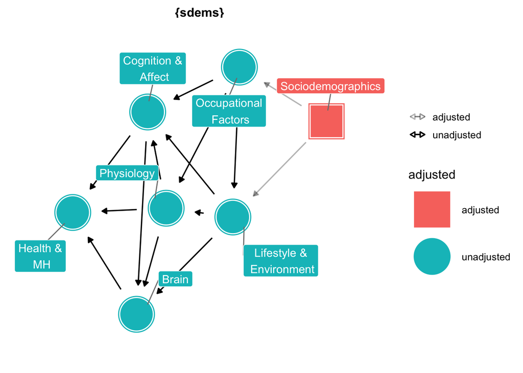

### Looking at the metaCats in more detail.

Categories falling under “Work”, i.e. “Employment”:

| Category |
| --- |
| Employment: Current |
| Other |
| Employment: History |

- Initially only looking at “Current” employment, instance 2, (unless “Time employed in main current job” (#757) is < 3/6 months, in which case take previous job if < 6 months ago, or “unemployed” otherwise).

Summary of all the fields under “Employment:Current”:

| Category | Field | FieldID | Value Type |
| --- | --- | --- | --- |
| Employment: Current | Time employed in main current job | 757 | Integer |
| Employment: Current | Length of working week for main job | 767 | Integer |
| Employment: Current | Frequency of travelling from home to job workplace | 777 | Integer |
| Employment: Current | Distance between home and job workplace | 796 | Integer |
| Employment: Current | Job involves mainly walking or standing | 806 | Categorical single |
| Employment: Current | Job involves heavy manual or physical work | 816 | Categorical single |
| Employment: Current | Job involves shift work | 826 | Categorical single |
| Employment: Current | Job involves night shift work | 3426 | Categorical single |
| Employment: Current | Current employment status | 6142 | Categorical multiple |
| Employment: Current | Transport type for commuting to job workplace | 6143 | Categorical multiple |

[output cut: 1 more lines]

- We are primarily interested in “Length of working week for main job” (#767). Problematic without knowing the hours worked in a week (e.g. 4 days/week: 30 or 60 hours?) [CORRECTION BELOW]. Also potentially problematic as it is a *categorical* variable [CORRECTION BELOW].
- We have this information below in the “Employment: History” section, i.e. “Work hours per week - exact value” (#22605). It seems bizare that you would have this info for past, but not current, employment so maybe we will also find this information for the current employment under this section?
- The distribution that produced the data will be far from normal weather we take days or hours worked - what to do about that?
- CORRECTION based on info [here](https://biobank.ndph.ox.ac.uk/showcase/field.cgi?id=767): “Length of working week for main job” (#767) is a continuous variable [integers, hours]. Has 4 instances, with instance 2 **at imaging visit** . This was collected from all the participants who indicated they were in paid employment or self-employed, as defined by their answers to [“Current employment status” (#6142)](https://biobank.ndph.ox.ac.uk/showcase/field.cgi?id=6142) .
- Aprox. 1000 participants have an Instance 3 (2019+) at the second imaging visit (see “Instances” here [here](https://biobank.ndph.ox.ac.uk/showcase/field.cgi?id=767)). Could be very useful for looking at any potential longitudinal effects + within-subj analyses.

Summary of all the fields under “Employment: History”:

| Category | Field | FieldID | Value Type |
| --- | --- | --- | --- |
| Employment: History | Year of birth | 22200 | Integer |
| Employment: History | Device used to enter occupational data | 22499 | Categorical single |
| Employment: History | When occupational data entered | 22500 | Date |
| Employment: History | Year ended full time education | 22501 | Integer |
| Employment: History | Number of jobs held | 22599 | Integer |
| Employment: History | Job coding | 22601 | Categorical single |
| Employment: History | Year job started | 22602 | Integer |
| Employment: History | Year job ended | 22603 | Integer |
| Employment: History | Work hours - lumped category | 22604 | Categorical single |
| Employment: History | Work hours per week - exact value | 22605 | Continuous |

[output cut: 34 more lines]

- Not exactly clear how good this data is for our purposes, at least initially when we are looking at hours worked. Perhaps we can look at hours worked in the previous job if the period in the current job is less than 3/6 months.
- “Participants were asked to enumerate their work history. Periods of 6 months or longer during which they were in paid full time employment for at least 15 hours each week have been labelled”jobs“, with all other periods labelled ‘gaps’”. [details here](https://biobank.ndph.ox.ac.uk/showcase/label.cgi?id=130)
- 121,276 participants in Online follow-up between 2015-06-24 and 2017-07-27. [details here](https://biobank.ndph.ox.ac.uk/showcase/field.cgi?id=22500)

Categories falling under “Sociodemographics”:

| Category |
| --- |
| Baseline |
| Ongoing |
| Household |
| Education |
| Ethnicity |
| Indices of Multiple Deprivation |

Summary of all the fields under “Sociodemographics”:

| Category | Field | FieldID | Value Type |
| --- | --- | --- | --- |
| Baseline | Sex | 31 | Categorical single |
| Baseline | Year of birth | 34 | Integer |
| Baseline | Month of birth | 52 | Categorical single |
| Baseline | Date of attending assessment centre | 53 | Date |
| Baseline | UK Biobank assessment centre | 54 | Categorical single |
| Baseline | Townsend deprivation index at recruitment | 189 | Continuous |
| Baseline | Age when attended assessment centre | 21003 | Integer |
| Baseline | Age at recruitment | 21022 | Integer |
| Education | Age completed full time education | 845 | Integer |
| Education | Qualifications | 6138 | Categorical multiple |

[output cut: 17 more lines]

Categories falling under “Lifestyle and environment”:

| Category |
| --- |
| Physical activity |
| Sleep |
| Smoking |
| Alcohol |

Summary of all the fields under “Lifestyle and environment”:

| Category | Field | FieldID | Value Type |
| --- | --- | --- | --- |
| Alcohol | Alcohol intake frequency. | 1558 | Categorical single |
| Alcohol | Average weekly red wine intake | 1568 | Integer |
| Alcohol | Average weekly champagne plus white wine intake | 1578 | Integer |
| Alcohol | Average weekly beer plus cider intake | 1588 | Integer |
| Alcohol | Average weekly spirits intake | 1598 | Integer |
| Alcohol | Average weekly fortified wine intake | 1608 | Integer |
| Alcohol | Alcohol usually taken with meals | 1618 | Categorical single |
| Alcohol | Alcohol intake versus 10 years previously | 1628 | Categorical single |
| Alcohol | Reason for reducing amount of alcohol drunk | 2664 | Categorical single |
| Alcohol | Former alcohol drinker | 3731 | Categorical single |

[output cut: 82 more lines]